# CSE 7324 Lab Assignment Three: Extending Logistic Regression

Xiangying Chang, Fang Qi, Rui Lin, Shimeng Yuan

# 1. Preparation and Overview

## 1.1 Business Understanding

In this lab we have chosen a dataset from Kaggle by scraping TripAdvisor (the famous tourism website) for information about restaurants for a given European city.The scraper goes through the restaurants listing pages and fulfills a raw dataset. The raw datasets for the main cities in Europe have been then curated for futher analysis purposes, and aggregated to obtain this dataset.

As a large restaurant company that shows restaurant reviews, TripAdvisor seeks to make users more convenient to choose satisfied restaurants by providing more information. After spending much time understanding the dataset and then use logistic regression model to predict the ratings, the result will help customers, restaurant owners and TripAdvisor to judge the quality of the restaurants.

As a result, we are able to help restaurant owners to know the influence of different factors on ratings of restaurants, so that they will know how to improve to attract more customers.They could change the location, adjust the cuisine type or get more positive reviews.And this will also help customers or gourmets to easily find their target restaurants.

For TripAdvisor, because it provides a scientific way for users to find appropriate restaurants, there will be more and more users relying on the website.The browsing time and number of users will increase so that the TripAdviosr will become more attractive and well known.

## 1.2 Data Understanding

First, we import the dataset into Python.

```python
# load data
import pandas as pd
import numpy as np
import seaborn as sns
import matplotlib as mpl
import matplotlib.pyplot as plt
import missingno as mn
import warnings
warnings.filterwarnings("ignore")

df = pd.read_csv('restaurants.csv')
print(df.info())
```

```
<class 'pandas.core.frame.DataFrame'>
RangeIndex: 125527 entries, 0 to 125526
Data columns (total 11 columns):
Unnamed: 0           125527 non-null int64
Name                 125527 non-null object
City                 125527 non-null object
Cuisine Style        94176 non-null object
Ranking              115876 non-null float64
Rating               115897 non-null float64
Price Range          77672 non-null object
Number of Reviews    108183 non-null float64
Reviews              115911 non-null object
URL_TA               125527 non-null object
ID_TA                125527 non-null object
dtypes: float64(3), int64(1), object(7)
memory usage: 10.5+ MB
None
```

The dataset contains 125527 variables and 11 features. The ranking, rating, number of reviews are numerical and other variables are categorical.The response variable is rating.

```python
df.head() # Show the name of each column
```

|  | Unnamed: 0 | Name | City | Cuisine Style | Ranking | Rating | Price Range | Number of Reviews | Reviews | URL_TA | ID_TA |
| --- | --- | --- | --- | --- | --- | --- | --- | --- | --- | --- | --- |
| 0 | 0 | Martine of Martine's Table | Amsterdam | ['French', 'Dutch', 'European'] | 1.0 | 5.0 | $$ - $$$ | 136.0 | [['Just like home', 'A Warm Welcome to Wintry ... | /Restaurant_Review-g188590-d11752080-Reviews-M... | d11752080 |
| 1 | 1 | De Silveren Spiegel | Amsterdam | ['Dutch', 'European', 'Vegetarian Friendly', '... | 2.0 | 4.5 | $$$$ | 812.0 | [['Great food and staff', 'just perfect'], ['0... | /Restaurant_Review-g188590-d693419-Reviews-De_... | d693419 |
| 2 | 2 | La Rive | Amsterdam | ['Mediterranean', 'French', 'International', '... | 3.0 | 4.5 | $$$$ | 567.0 | [['Satisfaction', 'Delicious old school restau... | /Restaurant_Review-g188590-d696959-Reviews-La_... | d696959 |
| 3 | 3 | Vinkeles | Amsterdam | ['French', 'European', 'International', 'Conte... | 4.0 | 5.0 | $$$$ | 564.0 | [['True five star dinner', 'A superb evening o... | /Restaurant_Review-g188590-d1239229-Reviews-Vi... | d1239229 |
| 4 | 4 | Librije's Zusje Amsterdam | Amsterdam | ['Dutch', 'European', 'International', 'Vegeta... | 5.0 | 4.5 | $$$$ | 316.0 | [['Best meal.... EVER', 'super food experience... | /Restaurant_Review-g188590-d6864170-Reviews-Li... | d6864170 |

```python
df.describe()
```

|  | Unnamed: 0 | Ranking | Rating | Number of Reviews |
| --- | --- | --- | --- | --- |
| count | 125527.000000 | 115876.000000 | 115897.000000 | 108183.000000 |
| mean | 3974.686131 | 3657.463979 | 3.987441 | 125.184983 |
| std | 4057.687698 | 3706.255301 | 0.678814 | 310.833311 |
| min | 0.000000 | 1.000000 | -1.000000 | 2.000000 |
| 25% | 1042.000000 | 965.000000 | 3.500000 | 9.000000 |
| 50% | 2445.000000 | 2256.000000 | 4.000000 | 32.000000 |
| 75% | 5626.000000 | 5237.000000 | 4.500000 | 114.000000 |
| max | 18211.000000 | 16444.000000 | 5.000000 | 16478.000000 |

```python
# Data description Table
description_table = pd.DataFrame()
description_table['Features'] = df.columns
description_table['Description'] = ['the number for the restaurants starting from 0','name of the restaurant','city location of the restaurant','cuisine style of the restaurant',
                                   'rank of the restaurant among the total number of restaurants in the city as a float object','rate of the restaurant on a scale from 1 to 5, as a float object',
                                   'price range of the restaurant among 3 categories as a categorical type','number of reviews that customers have let to the restaurant','2 reviews that are displayed on the restaurants scrolling page of the city'
                                   ,'part of the URL of the detailed restaurant page',' identification of the restaurant in the TA database constructed a one letter and a number']
description_table['Attributes'] = ['ratio'] + ['norminal']*3+['ratio']*2+['norminal']+ ['ratio']+ ['norminal'] * 3

description_table
```

|  | Features | Description | Attributes |
| --- | --- | --- | --- |
| 0 | Unnamed: 0 | the number for the restaurants starting from 0 | ratio |
| 1 | Name | name of the restaurant | norminal |
| 2 | City | city location of the restaurant | norminal |
| 3 | Cuisine Style | cuisine style of the restaurant | norminal |
| 4 | Ranking | rank of the restaurant among the total number ... | ratio |
| 5 | Rating | rate of the restaurant on a scale from 1 to 5,... | ratio |
| 6 | Price Range | price range of the restaurant among 3 categori... | norminal |
| 7 | Number of Reviews | number of reviews that customers have let to t... | ratio |
| 8 | Reviews | 2 reviews that are displayed on the restaurant... | norminal |
| 9 | URL_TA | part of the URL of the detailed restaurant page | norminal |
| 10 | ID_TA | identification of the restaurant in the TA da... | norminal |

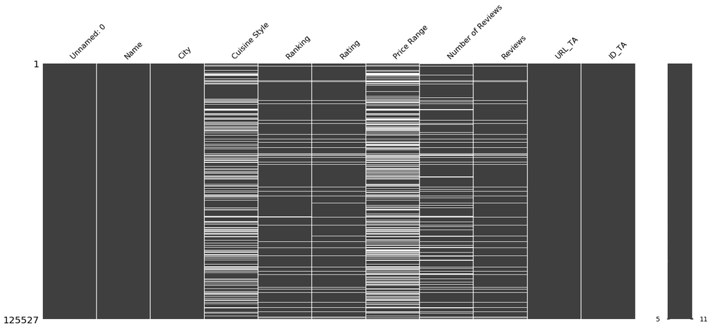

```python
mn.matrix(df.sort_values(by=["Name",]))
```

We can see from the graph that there are many missing values.In order to complete the cleaning process, we need to sum up the number of thr missing value under each column.

```python
print(df.isnull().sum())
```

```
Unnamed: 0               0
Name                     0
City                     0
Cuisine Style        31351
Ranking               9651
Rating                9630
Price Range          47855
Number of Reviews    17344
Reviews               9616
URL_TA                   0
ID_TA                    0
dtype: int64
```

```python
df_notnull = df[(df['Cuisine Style'].notnull()) & (df['Rating'].notnull()) & (df['Number of Reviews'].notnull())
                     & (df['Price Range'].notnull())]
df_notnull.info()
```

```
<class 'pandas.core.frame.DataFrame'>
Int64Index: 74239 entries, 0 to 125445
Data columns (total 11 columns):
Unnamed: 0           74239 non-null int64
Name                 74239 non-null object
City                 74239 non-null object
Cuisine Style        74239 non-null object
Ranking              74225 non-null float64
Rating               74239 non-null float64
Price Range          74239 non-null object
Number of Reviews    74239 non-null float64
Reviews              74239 non-null object
URL_TA               74239 non-null object
ID_TA                74239 non-null object
dtypes: float64(3), int64(1), object(7)
memory usage: 6.8+ MB
```

We think duplicate data here for restaurant is more likely be mistaken,because it is less possibe that the restaurants have all same features, so we decide to drop duplicate data.

```python
df_dropduplicates = df_notnull.drop_duplicates(['Unnamed: 0',])
df_dropduplicates.info()
```

```
<class 'pandas.core.frame.DataFrame'>
Int64Index: 13274 entries, 0 to 115025
Data columns (total 11 columns):
Unnamed: 0           13274 non-null int64
Name                 13274 non-null object
City                 13274 non-null object
Cuisine Style        13274 non-null object
Ranking              13267 non-null float64
Rating               13274 non-null float64
Price Range          13274 non-null object
Number of Reviews    13274 non-null float64
Reviews              13274 non-null object
URL_TA               13274 non-null object
ID_TA                13274 non-null object
dtypes: float64(3), int64(1), object(7)
memory usage: 1.2+ MB
```

```python
# drop these features showed above and few others which I don't need under same purpose
df_new = df_dropduplicates.drop(['Unnamed: 0', 'Ranking', 'Reviews', 'URL_TA','ID_TA'], 1)
df_new.info()
```

```
<class 'pandas.core.frame.DataFrame'>
Int64Index: 13274 entries, 0 to 115025
Data columns (total 6 columns):
Name                 13274 non-null object
City                 13274 non-null object
Cuisine Style        13274 non-null object
Rating               13274 non-null float64
Price Range          13274 non-null object
Number of Reviews    13274 non-null float64
dtypes: float64(2), object(4)
memory usage: 725.9+ KB
```

We treat "Price Range" as a 3-category classification problem, grouping price range from 1 to 3

```python
#convert the Price Range to numrical indicator
priceRangeDict = {'$': 1, '$$ - $$$': 2, '$$$$': 3}
df_convert = df_new.copy()
df_convert['Price Range'] = df_new['Price Range'].map(priceRangeDict)
df_convert.head()
```

|  | Name | City | Cuisine Style | Rating | Price Range | Number of Reviews |
| --- | --- | --- | --- | --- | --- | --- |
| 0 | Martine of Martine's Table | Amsterdam | ['French', 'Dutch', 'European'] | 5.0 | 2 | 136.0 |
| 1 | De Silveren Spiegel | Amsterdam | ['Dutch', 'European', 'Vegetarian Friendly', '... | 4.5 | 3 | 812.0 |
| 2 | La Rive | Amsterdam | ['Mediterranean', 'French', 'International', '... | 4.5 | 3 | 567.0 |
| 3 | Vinkeles | Amsterdam | ['French', 'European', 'International', 'Conte... | 5.0 | 3 | 564.0 |
| 4 | Librije's Zusje Amsterdam | Amsterdam | ['Dutch', 'European', 'International', 'Vegeta... | 4.5 | 3 | 316.0 |

```python
#convert the Name to numrical indicator
nameDict = {}
for i, name in enumerate(df_convert['Name'].unique()):
    nameDict[name] = i
df_convert['Name'] = df_new['Name'].map(nameDict)
df_convert.head()
```

|  | Name | City | Cuisine Style | Rating | Price Range | Number of Reviews |
| --- | --- | --- | --- | --- | --- | --- |
| 0 | 0 | Amsterdam | ['French', 'Dutch', 'European'] | 5.0 | 2 | 136.0 |
| 1 | 1 | Amsterdam | ['Dutch', 'European', 'Vegetarian Friendly', '... | 4.5 | 3 | 812.0 |
| 2 | 2 | Amsterdam | ['Mediterranean', 'French', 'International', '... | 4.5 | 3 | 567.0 |
| 3 | 3 | Amsterdam | ['French', 'European', 'International', 'Conte... | 5.0 | 3 | 564.0 |
| 4 | 4 | Amsterdam | ['Dutch', 'European', 'International', 'Vegeta... | 4.5 | 3 | 316.0 |

```python
#convert the City to numrical indicator
cityDict = {}
for i, city in enumerate(df_convert['City'].unique()):
    cityDict[city] = i
df_convert['City'] = df_new['City'].map(cityDict)
df_convert.head()
```

|  | Name | City | Cuisine Style | Rating | Price Range | Number of Reviews |
| --- | --- | --- | --- | --- | --- | --- |
| 0 | 0 | 0 | ['French', 'Dutch', 'European'] | 5.0 | 2 | 136.0 |
| 1 | 1 | 0 | ['Dutch', 'European', 'Vegetarian Friendly', '... | 4.5 | 3 | 812.0 |
| 2 | 2 | 0 | ['Mediterranean', 'French', 'International', '... | 4.5 | 3 | 567.0 |
| 3 | 3 | 0 | ['French', 'European', 'International', 'Conte... | 5.0 | 3 | 564.0 |
| 4 | 4 | 0 | ['Dutch', 'European', 'International', 'Vegeta... | 4.5 | 3 | 316.0 |

```python
#convert the Cuisine Style to numrical indicator
styleDict = {}
for i, style in enumerate(df_convert['Cuisine Style'].unique()):
    styleDict[style] = i
df_convert['Cuisine Style'] = df_new['Cuisine Style'].map(styleDict)
df_convert.head()
```

|  | Name | City | Cuisine Style | Rating | Price Range | Number of Reviews |
| --- | --- | --- | --- | --- | --- | --- |
| 0 | 0 | 0 | 0 | 5.0 | 2 | 136.0 |
| 1 | 1 | 0 | 1 | 4.5 | 3 | 812.0 |
| 2 | 2 | 0 | 2 | 4.5 | 3 | 567.0 |
| 3 | 3 | 0 | 3 | 5.0 | 3 | 564.0 |
| 4 | 4 | 0 | 4 | 4.5 | 3 | 316.0 |

To improve our accuracy and find the correlated variables,we will investigate the correlations among these variables.

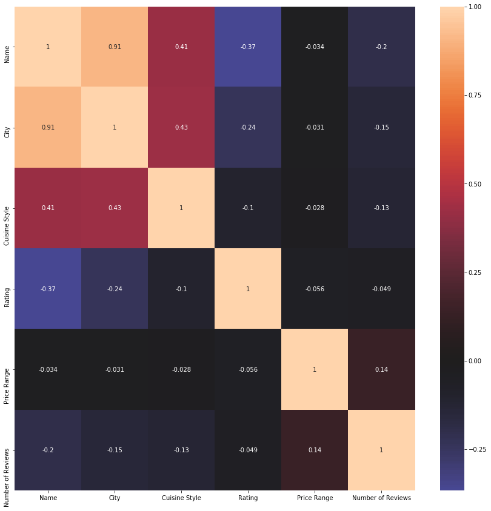

```python
# show the relationship between attributes
import seaborn as sns
import matplotlib.pyplot as plt
f, ax = plt.subplots(figsize=(12, 12))
sns.heatmap(df_convert.corr(), annot=True, center=0)
f.tight_layout()
```

```python
#The number of reviews has little connection to our result,so we delete it to improve the accurancy.
del df_convert['Number of Reviews']
```

We want to investgate the relationship between rating and price range to show the distribution of different classes in price range.

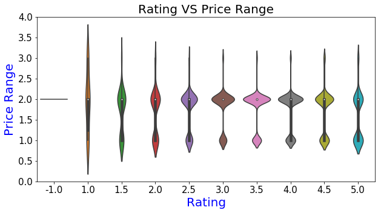

```python
#Rating with Price Range

plt.figure(figsize=(10, 5))
plt.xticks(fontsize=15)
plt.yticks(fontsize=15)
#plt.ylim((0, 25000))
plt.title('Rating VS Price Range', fontsize=20)
plt.xlabel('$Rating$', fontsize=20, color='blue')
plt.ylabel('$Price Range$', fontsize=20, color='blue')
sns.violinplot(x='Rating',y='Price Range',data=df_convert)
```

What we can see from the violinplot is that there is a weak relationship between rating and price range, just as the heatmap shows. But it still shows that the price range is higher, the rating is a little lower, which is reasonable.

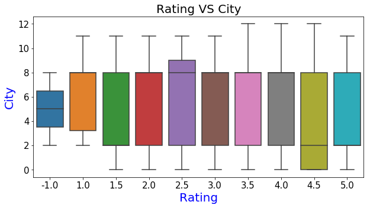

```python
#Rating with city
plt.figure(figsize=(10, 5))
plt.xticks(fontsize=15)
plt.yticks(fontsize=15)
#plt.ylim((0, 25000))
plt.title('Rating VS City', fontsize=20)
plt.xlabel('$Rating$', fontsize=20, color='blue')
plt.ylabel('$City$', fontsize=20, color='blue')
sns.boxplot(x='Rating',y='City',data=df_convert)
```

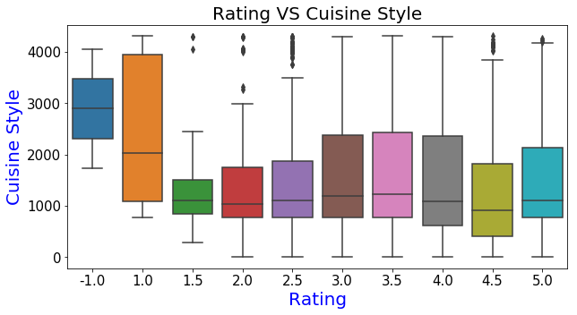

```python
#Rating with Cuisine Style
plt.figure(figsize=(10, 5))
plt.xticks(fontsize=15)
plt.yticks(fontsize=15)
#plt.ylim((0, 25000))
plt.title('Rating VS Cuisine Style', fontsize=20)
plt.xlabel('$Rating$', fontsize=20, color='blue')
plt.ylabel('$Cuisine Style$', fontsize=20, color='blue')
sns.boxplot(x='Rating',y='Cuisine Style',data=df_convert)
```

It is obvious that the restaurants with rating of 3,3.5 and 4 have all the cuisine styles.The restaurants whose rating is 1.5 only has 2000 kinds of cuisine styles.

```python
df_convert
```

|  | Name | City | Cuisine Style | Rating | Price Range |
| --- | --- | --- | --- | --- | --- |
| 0 | 0 | 0 | 0 | 5.0 | 2 |
| 1 | 1 | 0 | 1 | 4.5 | 3 |
| 2 | 2 | 0 | 2 | 4.5 | 3 |
| 3 | 3 | 0 | 3 | 5.0 | 3 |
| 4 | 4 | 0 | 4 | 4.5 | 3 |
| 5 | 5 | 0 | 5 | 4.5 | 3 |
| 6 | 6 | 0 | 6 | 4.5 | 2 |
| 7 | 7 | 0 | 7 | 4.5 | 3 |
| 8 | 8 | 0 | 8 | 4.5 | 3 |
| 9 | 9 | 0 | 9 | 4.5 | 1 |
| 10 | 10 | 0 | 10 | 4.5 | 2 |
| 11 | 11 | 0 | 11 | 4.5 | 2 |
| 12 | 12 | 0 | 12 | 4.5 | 3 |
| 13 | 13 | 0 | 13 | 4.5 | 2 |
| 14 | 14 | 0 | 11 | 4.5 | 3 |
| 15 | 15 | 0 | 14 | 4.5 | 2 |
| 16 | 16 | 0 | 15 | 4.5 | 1 |
| 17 | 17 | 0 | 16 | 4.5 | 3 |
| 18 | 18 | 0 | 17 | 4.5 | 2 |
| 19 | 19 | 0 | 18 | 4.5 | 2 |
| 20 | 20 | 0 | 19 | 4.5 | 3 |
| 21 | 21 | 0 | 20 | 4.5 | 3 |
| 22 | 22 | 0 | 4 | 4.5 | 2 |
| 24 | 23 | 0 | 21 | 4.5 | 2 |
| 25 | 24 | 0 | 22 | 4.5 | 2 |
| 26 | 25 | 0 | 23 | 4.5 | 3 |
| 27 | 26 | 0 | 24 | 4.5 | 1 |
| 28 | 27 | 0 | 4 | 4.5 | 2 |
| 29 | 28 | 0 | 25 | 4.5 | 2 |
| 30 | 29 | 0 | 26 | 4.5 | 2 |
| ... | ... | ... | ... | ... | ... |
| 103097 | 12321 | 11 | 551 | 2.0 | 2 |
| 103099 | 12322 | 11 | 4301 | 2.0 | 2 |
| 103112 | 12323 | 11 | 558 | 2.5 | 2 |
| 103172 | 12324 | 11 | 4302 | 2.0 | 2 |
| 103180 | 12325 | 11 | 918 | 2.5 | 2 |
| 103182 | 12326 | 11 | 479 | 2.0 | 2 |
| 103184 | 12327 | 11 | 4276 | 2.0 | 2 |
| 103185 | 12328 | 11 | 4303 | 2.0 | 2 |
| 103189 | 11869 | 11 | 551 | 2.5 | 2 |
| 103192 | 12329 | 11 | 919 | 2.5 | 3 |
| 103195 | 2302 | 11 | 841 | 2.0 | 1 |
| 103209 | 2417 | 11 | 551 | 2.0 | 2 |
| 103219 | 12330 | 11 | 4304 | 2.0 | 2 |
| 103231 | 12331 | 11 | 1729 | 2.5 | 2 |
| 103238 | 12332 | 11 | 4305 | 2.5 | 3 |
| 103243 | 12333 | 11 | 1016 | 2.0 | 2 |
| 103245 | 12334 | 11 | 551 | 3.5 | 2 |
| 103253 | 4695 | 11 | 1147 | 2.5 | 2 |
| 103254 | 12335 | 11 | 4306 | 3.5 | 1 |
| 103256 | 12336 | 11 | 4307 | 1.5 | 2 |
| 103258 | 12337 | 11 | 551 | 1.5 | 1 |
| 103260 | 12338 | 11 | 815 | 2.0 | 1 |
| 103263 | 12339 | 11 | 781 | 2.5 | 2 |
| 103272 | 12340 | 11 | 4308 | 1.5 | 2 |
| 103274 | 12341 | 11 | 841 | 2.0 | 1 |
| 103313 | 12342 | 11 | 4309 | 1.0 | 2 |
| 103328 | 12343 | 11 | 841 | 1.0 | 2 |
| 114053 | 12344 | 12 | 4310 | 3.5 | 2 |
| 114163 | 12345 | 12 | 4311 | 4.5 | 1 |
| 115025 | 12346 | 12 | 861 | 4.0 | 2 |

13274 rows × 5 columns

## 1.3 data spilt

A convenient way to randomly partition this dataset into a separate test and training dataset is to use the train_test_split function from scikit-learn's cross_validation submodule.Using the cross validation modules will help us spilt 80% of data for training set and 20% of data for testing set.

```python
from sklearn.model_selection import train_test_split
train_size = 0.80
test_size = 1 - train_size
train, test = train_test_split(df_convert, train_size=train_size)
print('Compare Data Set Size')
print('==========================')
print('Original Dataset size: {}'.format(df_convert.shape))
print('Train size: {}'.format(train.shape))
print('Test size: {}'.format(test.shape))
```

```
Compare Data Set Size
==========================
Original Dataset size: (13274, 5)
Train size: (10619, 5)
Test size: (2655, 5)
```

```python
from sklearn import preprocessing
X = df_convert
y = df_convert['Rating']
# del X['Rating']
y_train = train['Rating']
X_train = train
X_test = test
y_test = test['Rating']
# del X_train['Rating']
# del X_test['Rating']
lab_enc = preprocessing.LabelEncoder()
y_train = lab_enc.fit_transform(y_train)
y_test = lab_enc.fit_transform(y_test)
```

# 2. Modeling

## 2.1 Create a custom, one-versus-all logistic regression classifier

```python
from sklearn.metrics import accuracy_score
from scipy.special import expit
from scipy.optimize import fmin_bfgs
from numpy.linalg import pinv
from sklearn import metrics as mt
from ipywidgets import widgets as wd
```

```python
class BinaryLogisticRegression:
    def __init__(self, eta, iterations, C, method, regularization):
        self.eta = eta
        self.iters = iterations
        self.C = C
        self.method = method
        self.regularization = regularization
        # internally we will store the weights as self.w_ to keep with sklearn conventions

    def __str__(self):
        if(hasattr(self,'w_')):
            return 'Binary Logistic Regression Object with coefficients:\n'+ str(self.w_) # is we have trained the object
        else:
            return 'Untrained Binary Logistic Regression Object'

    # convenience, private:
    @staticmethod
    def _add_bias(X):
        return np.hstack((np.ones((X.shape[0],1)),X)) # add bias term

    @staticmethod
    def _sigmoid(theta):
        # increase stability, redefine sigmoid operation
        return expit(theta) #1/(1+np.exp(-theta))
    @staticmethod
    def objective_gradient(w,X,y,C):
        g = expit(X @ w)
        ydiff = y-g # get y difference
        gradient = np.mean(X * ydiff[:,np.newaxis], axis=0)
        gradient = gradient.reshape(w.shape)
        gradient[1:] += 2 * w[1:] * C
        return -gradient

    # vectorized gradient calculation
    def _get_gradient_steepest(self,X,y):
        ydiff = y-self.predict_proba(X,add_bias=False).ravel() # get y difference
        gradient = np.mean(X * ydiff[:,np.newaxis], axis=0) # make ydiff a column vector and multiply through

        gradient = gradient.reshape(self.w_.shape)

        return gradient

    def _get_gradient_stochastic(self,X,y):
        idx = int(np.random.rand()*len(y)) # grab random instance
        ydiff = y[idx]-self.predict_proba(X[idx],add_bias=False) # get y difference (now scalar)
        gradient = X[idx] * ydiff[:,np.newaxis] # make ydiff a column vector and multiply through

        gradient = gradient.reshape(self.w_.shape)

        return gradient

    def _get_gradient_newton(self,X,y):
        g = self.predict_proba(X,add_bias=False).ravel() # get sigmoid value for all classes
        hessian = X.T @ np.diag(g*(1-g)) @ X - 2 * self.C # calculate the hessian

        ydiff = y-g # get y difference
        gradient = np.sum(X * ydiff[:,np.newaxis], axis=0) # make ydiff a column vector and multiply through
        gradient = gradient.reshape(self.w_.shape)

        return pinv(hessian) @ gradient


    def _regularization(self,gradient):
        if self.regularization == "L1":
            gradient[1:] += -abs(self.w_[1:]) * self.C
        elif self.regularization == "L2":
            gradient[1:] += -2 * self.w_[1:] * self.C
        elif self.regularization == "L1L2":
            gradient[1:] += -2 * self.w_[1:] * self.C-abs(self.w_[1:]) * self.C
        else:
            gradient[1:] += 0

        return gradient


    def _get_gradient(self,X,y):
        if self.method == "steepest":
            gradient = self._get_gradient_steepest(X, y)
        if self.method == "stochastic":
            gradient = self._get_gradient_stochastic(X, y)
        if self.method == "newton":
            gradient = self._get_gradient_newton(X, y)

        return self._regularization(gradient)



    # public:
    def predict_proba(self,X,add_bias=True):
        # add bias term if requested
        Xb = self._add_bias(X) if add_bias else X
        return self._sigmoid(Xb @ self.w_) # return the probability y=1

    def predict(self,X):
        return (self.predict_proba(X)>0.5) #return the actual prediction


    def fit(self, X, y):
        Xb = self._add_bias(X) # add bias term
        num_samples, num_features = Xb.shape

        self.w_ = np.zeros((num_features,1)) # init weight vector to zeros

        # for as many as the max iterations
        for _ in range(self.iters):
            gradient = self._get_gradient(Xb,y)
            self.w_ += gradient*self.eta # multiply by learning rate
```

```python
class LogisticRegression:
    def __init__(self, eta, iterations, C, method, regularization):
        self.eta = eta
        self.iterations = iterations
        self.C = C
        self.method = method
        self.regularization = regularization
        # internally we will store the weights as self.w_ to keep with sklearn conventions

    def __str__(self):
        if(hasattr(self,'w_')):
            return 'MultiClass Logistic Regression Object with coefficients:\n'+ str(self.w_) # is we have trained the object
        else:
            return 'Untrained MultiClass Logistic Regression Object'

    def fit(self,X,y):
        num_samples, num_features = X.shape
        self.unique_ = np.unique(y) # get each unique class value
        num_unique_classes = len(self.unique_)
        self.classifiers_ = [] # will fill this array with binary classifiers

        for i,yval in enumerate(self.unique_): # for each unique value
            y_binary = y==yval # create a binary problem
            # train the binary classifier for this class
            blr = BinaryLogisticRegression(eta = self.eta,iterations = self.iterations,C = self.C,method = self.method, regularization=self.regularization)
            blr.fit(X,y_binary)
            # add the trained classifier to the list
            self.classifiers_.append(blr)

        # save all the weights into one matrix, separate column for each class
        self.w_ = np.hstack([x.w_ for x in self.classifiers_]).T

    def predict_proba(self,X):
        probs = []
        for blr in self.classifiers_:
            probs.append(blr.predict_proba(X)) # get probability for each classifier

        return np.hstack(probs) # make into single matrix

    def predict(self,X):
        return np.argmax(self.predict_proba(X),axis=1) # take argmax along row
```

## 2.2 Train classifier to achieve good generalization performance.

### Adjust C

For 'steepest' and 'stochastic', we set eta = 0.05, iterations = 1000 as defult number. By adjusting C, we can select which regularization is the best for each method.

### 2.2.1 Steepest descent

```python
from matplotlib import pyplot as plt
import time
%matplotlib inline
```

```python
%%time
start_time = time.time()
regs = ["L1","L2","L1L2"]
acc = []
best_accuracy=0
for C in np.arange(0.01,0.1,0.01):
    lr = LogisticRegression(eta=0.05, iterations=1000, method='steepest',  regularization="L1", C = C)
    lr.fit(X_train, y_train)
    yhat = lr.predict(X_test)
    acc.append(mt.accuracy_score(y_test,yhat))
    acc1 = np.array(acc)
    if(accuracy_score(y_test,yhat)>best_accuracy):
        best_accuracy = accuracy_score(y_test,yhat)
        best_C = C
        time1 = time.time()-start_time
```

```
CPU times: user 1min 39s, sys: 6.75 s, total: 1min 46s
Wall time: 54 s
```

```python
%%time
start_time2 = time.time()
acc = []
best_accuracy2=0
for C in np.arange(0.01,0.1,0.01):
    lr = LogisticRegression(eta=0.05, iterations=1000, method='steepest',  regularization="L2", C = C)
    lr.fit(X_train, y_train)
    yhat = lr.predict(X_test)
    acc.append(mt.accuracy_score(y_test,yhat))
    acc2 = np.array(acc)
    if(accuracy_score(y_test,yhat)>best_accuracy2):
        best_accuracy2 = accuracy_score(y_test,yhat)
        best_C2 = C
        time2 = time.time()-start_time2
```

```
CPU times: user 1min 40s, sys: 6.78 s, total: 1min 47s
Wall time: 54.7 s
```

```python
%%time
start_time3 = time.time()
acc = []
best_accuracy3=0
for C in np.arange(0.01,0.1,0.01):
    lr = LogisticRegression(eta=0.05, iterations=1000, method='steepest',  regularization="L1L2", C = C)
    lr.fit(X_train, y_train)
    yhat = lr.predict(X_test)
    acc.append(mt.accuracy_score(y_test,yhat))
    acc3 = np.array(acc)
    if(accuracy_score(y_test,yhat)>best_accuracy3):
        best_accuracy3 = accuracy_score(y_test,yhat)
        best_C3 = C
        time3 = time.time()-start_time3
```

```
CPU times: user 1min 43s, sys: 6.89 s, total: 1min 50s
Wall time: 56.6 s
```

```python
print('best accuracy for L1:',best_accuracy,',C:',best_C, ', Time:', time1)
print('best accuracy for L2:',best_accuracy2,',C:',best_C2, ', Time:', time2)
print('best accuracy for L1L2:',best_accuracy3,',C:',best_C3, ', Time:', time3)
```

```
best accuracy for L1: 0.27080979284369117 ,C: 0.01 , Time: 6.294733762741089
best accuracy for L2: 0.3032015065913371 ,C: 0.09 , Time: 54.716615200042725
best accuracy for L1L2: 0.2896421845574388 ,C: 0.060000000000000005 , Time: 37.27816677093506
```

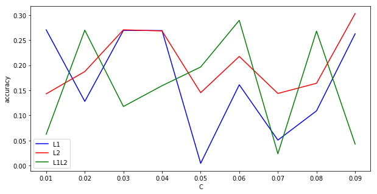

```python
plt.figure(figsize=(10, 5))
c = np.arange(0.01,0.1,0.01)
plt.plot(c,acc1,color = 'blue', label = "L1")
plt.plot(c,acc2, color = 'red',label = "L2")
plt.plot(c,acc3, color = 'green',label = "L1L2")
plt.xlabel('C')
plt.ylabel('accuracy')
plt.legend()
```

### 2.2.2 stochastic gradient descent

```python
%%time
start_time4 = time.time()
acc = []
best_accuracy4=0
for C in np.arange(0.01,0.1,0.01):
    lr = LogisticRegression(eta=0.05, iterations=1000, method='stochastic',  regularization="L1", C = C)
    lr.fit(X_train, y_train)
    yhat = lr.predict(X_test)
    acc.append(mt.accuracy_score(y_test,yhat))
    acc4 = np.array(acc)
    if(accuracy_score(y_test,yhat)>best_accuracy4):
        best_accuracy4 = accuracy_score(y_test,yhat)
        best_C4 = C
        time4 = time.time()-start_time4
```

```
CPU times: user 6.94 s, sys: 135 ms, total: 7.07 s
Wall time: 7.41 s
```

```python
%%time
start_time5 = time.time()
acc = []
best_accuracy5=0
for C in np.arange(0.01,0.1,0.01):
    lr = LogisticRegression(eta=0.05, iterations=1000, method='stochastic',  regularization="L2", C = C)
    lr.fit(X_train, y_train)
    yhat = lr.predict(X_test)
    acc.append(mt.accuracy_score(y_test,yhat))
    acc5 = np.array(acc)
    if(accuracy_score(y_test,yhat)>best_accuracy5):
        best_accuracy5 = accuracy_score(y_test,yhat)
        best_C5 = C
        time5 = time.time()-start_time5
```

```
CPU times: user 7.07 s, sys: 123 ms, total: 7.19 s
Wall time: 7.42 s
```

```python
%%time
start_time6 = time.time()
acc = []
best_accuracy6=0
for C in np.arange(0.01,0.1,0.01):
    lr = LogisticRegression(eta=0.05, iterations=1000, method='stochastic',  regularization="L1L2", C = C)
    lr.fit(X_train, y_train)
    yhat = lr.predict(X_test)
    acc.append(mt.accuracy_score(y_test,yhat))
    acc6 = np.array(acc)
    if(accuracy_score(y_test,yhat)>best_accuracy6):
        best_accuracy6 = accuracy_score(y_test,yhat)
        best_C6 = C
        time6 = time.time()-start_time6
```

```
CPU times: user 7.77 s, sys: 132 ms, total: 7.9 s
Wall time: 8.14 s
```

```python
print('best accuracy for L1:',best_accuracy4,',C:',best_C4, ', Time:', time4)
print('best accuracy for L2:',best_accuracy5,',C:',best_C5, ', Time:', time5)
print('best accuracy for L1L2:',best_accuracy6,',C:',best_C6, ', Time:', time6)
```

```
best accuracy for L1: 0.3032015065913371 ,C: 0.06999999999999999 , Time: 5.727025747299194
best accuracy for L2: 0.3032015065913371 ,C: 0.06999999999999999 , Time: 5.590264797210693
best accuracy for L1L2: 0.27005649717514124 ,C: 0.05 , Time: 4.630419969558716
```

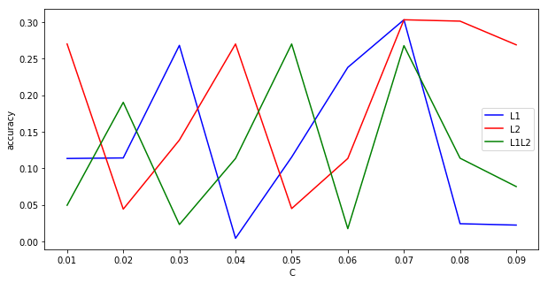

```python
plt.figure(figsize=(10, 5))
c = np.arange(0.01,0.1,0.01)
plt.plot(c,acc4,color = 'blue', label = "L1")
plt.plot(c,acc5, color = 'red',label = "L2")
plt.plot(c,acc6, color = 'green',label = "L1L2")
plt.xlabel('C')
plt.ylabel('accuracy')
plt.legend()
```

According to results and plot, we can get that when regularization = 'L1' and 'L2', accuracy is the same, so we consider the time for these regularizations. When regularization = 'L1', time is 7.07s which is less than the time for 'L2' 7.19s, so we think when regularization = 'L1', C= '0.069999', we can get the best accuracy which equals to 0.3032015065913371, the result is best. So we will use 'L1' for stochastic method.

### 2.2.3 Newton's method

```python
%%time
start_time7 = time.time()
lr = LogisticRegression(eta=0.1, iterations=1, method='newton',  regularization= 'L1', C = 0.001)
lr.fit(X_train, y_train)
yhat = lr.predict(X_test)
time7 = time.time()-start_time7
```

```
CPU times: user 12 s, sys: 10.1 s, total: 22.1 s
Wall time: 14.5 s
```

```python
%%time
start_time8 = time.time()
lr2 = LogisticRegression(eta=0.1, iterations=1, method='newton',  regularization= 'L2', C = 0.001)
lr2.fit(X_train, y_train)
yhat2 = lr2.predict(X_test)
time8 = time.time()-start_time8
```

```
CPU times: user 12.2 s, sys: 10.1 s, total: 22.3 s
Wall time: 13 s
```

```python
%%time
start_time9 = time.time()
lr3 = LogisticRegression(eta=0.1, iterations=1, method='newton',  regularization= 'L1L2', C = 0.001)
lr3.fit(X_train, y_train)
yhat3 = lr3.predict(X_test)
time9 = time.time()-start_time9
```

```
CPU times: user 12.2 s, sys: 10.3 s, total: 22.5 s
Wall time: 14.8 s
```

```python
new_accuracy1 = accuracy_score(y_test,yhat)
new_accuracy2 = accuracy_score(y_test,yhat2)
new_accuracy3 = accuracy_score(y_test,yhat3)
```

```python
print('Accuracy of L1: ',new_accuracy1, ', Time:', time7)
print('Accuracy of L2: ',new_accuracy2, ', Time:', time8)
print('Accuracy of L1L2: ',new_accuracy3, ', Time:', time9)
```

```
Accuracy of L1:  0.696798493408663 , Time: 14.548057079315186
Accuracy of L2:  0.696798493408663 , Time: 13.004170894622803
Accuracy of L1L2:  0.696798493408663 , Time: 14.830077886581421
```

Compare these three methods, we can get the result that when method = 'newton', regularization = 'L1', C = '0.001', the accuracy is the best which equals to 0.696798493408663 , time is 22.1s.

### 2.2.4 Data snooping

We think data snooping is involved in our case. Firstly, we split data into traning set and testing set, the purpose for our case is to select appropriate parameters and optimize our models as well as possible in training data. Then we choose the final parameters, test the performance by using testing data to examine whether the model is good enough. We adjust parameter C and select best method to avoid overfitting and underfitting. These process shows that data snooping is involved with our ways of selecting parameters

## 2.3 Comparison with Scikit-learn

### 2.3.1 Accuracy and Running Time of scikit-learn

```python
%%time
from sklearn.linear_model import LogisticRegression as SKLogisticRegression
start_time10 = time.time()
lr_sk = SKLogisticRegression() # all params default

lr_sk.fit(X_train, y_train)

yhat = lr_sk.predict(X_test)
time10 = time.time()-start_time10
sci_accuracy = accuracy_score(y_test,yhat)
print('Accuracy of: ',sci_accuracy, ', Time:', time10)
```

```
Accuracy of:  0.5672316384180791 , Time: 1.1979122161865234
CPU times: user 814 ms, sys: 42.8 ms, total: 857 ms
Wall time: 1.2 s
```

### 2.3.2 Comarison Table

```python
import seaborn as sns
import matplotlib.pyplot as plt
com= pd.DataFrame
index = ['Steepest_L1', 'Steepest_L2','Steepest_L1L2','Stochnastic_L1', 'Stochnastic_L2', 'Stochnastic_L1L2', 'Newtone_L1','Newtone_L2','Newtone_L1L2', 'ScikitLearn']

columns = ['Method', 'Accuracy','Running Time']
com = pd.DataFrame(columns=columns)
accuracy = (best_accuracy,best_accuracy2,best_accuracy3,best_accuracy4,best_accuracy5,best_accuracy6,new_accuracy1,new_accuracy2,new_accuracy3,sci_accuracy)
running_time = (time1,time2,time3,time4,time5,time6,time7,time8,time9,time10)

com['Method'] = index
com['Accuracy'] = np.array(accuracy)
com['Running Time'] = np.array(running_time)
com
```

|  | Method | Accuracy | Running Time |
| --- | --- | --- | --- |
| 0 | Steepest_L1 | 0.270810 | 6.294734 |
| 1 | Steepest_L2 | 0.303202 | 54.716615 |
| 2 | Steepest_L1L2 | 0.289642 | 37.278167 |
| 3 | Stochnastic_L1 | 0.303202 | 5.727026 |
| 4 | Stochnastic_L2 | 0.303202 | 5.590265 |
| 5 | Stochnastic_L1L2 | 0.270056 | 4.630420 |
| 6 | Newtone_L1 | 0.696798 | 14.548057 |
| 7 | Newtone_L2 | 0.696798 | 13.004171 |
| 8 | Newtone_L1L2 | 0.696798 | 14.830078 |
| 9 | ScikitLearn | 0.567232 | 1.197912 |

The table shows the comparison between the Accuracy and Running time of different methods. The Newton and ScikiLearn methods have better accuracy than Steepest and Stochnastic methods. ScikitLearn method is the fastest. The running time of Stochnastic is also good. The Steepest method has the longest running time with its best accuracy. Newton's Running time is like 10 times longer than ScikitLearn. Next, we will provide visualization of these methods.

### 2.3.3 Comparison Visualization

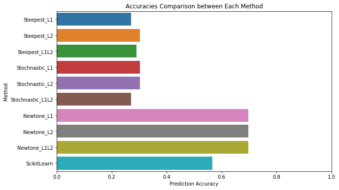

```python
f, ax = plt.subplots(figsize=(10,6))

ax = sns.barplot(x="Accuracy", y='Method', data=com)
ax.set(xlim=(0, 1),
       xlabel="Prediction Accuracy")
plt.title('Accuracies Comparison between Each Method')
plt.show()
```

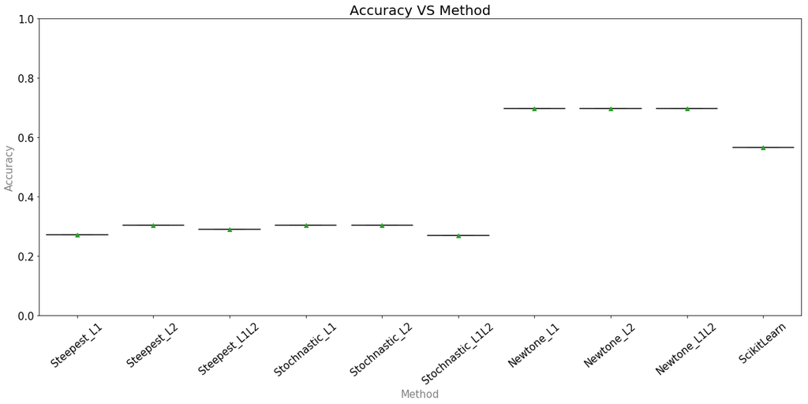

```python
plt.figure(figsize=(20, 8))
plt.xticks(fontsize=15,rotation=40)
plt.yticks(fontsize=15)
plt.ylim((0, 1))
plt.title('Accuracy VS Method', fontsize=20)
plt.xlabel('Method', fontsize=15, color='gray')
plt.ylabel('Accuracy', fontsize=15, color='gray')
sns.boxplot(x='Method', y='Accuracy', data=com, sym='r*', meanline=False, showmeans=True)
```

From the plots showed above, we can tell that steepest method and stochnastic method have almost same accuracy, and they are much lower than the accuracy of Newton and Scikitlearn. Newton got the best accuracy in this dataset.

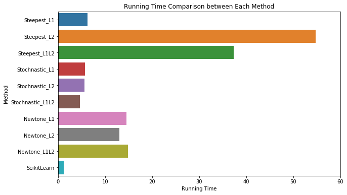

```python
f, ax = plt.subplots(figsize=(10,6))

ax = sns.barplot(x="Running Time", y='Method', data=com)
ax.set(xlim=(0, 60),
       xlabel="Running Time")
plt.title('Running Time Comparison between Each Method')
plt.show()
```

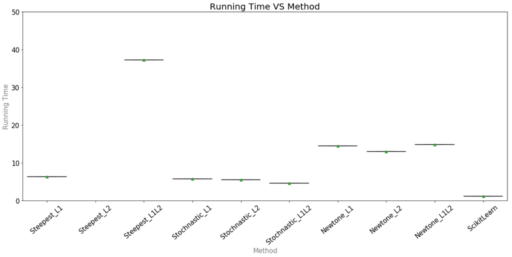

```python
plt.figure(figsize=(20, 8))
plt.xticks(fontsize=15,rotation=40)
plt.yticks(fontsize=15)
plt.ylim((0, 50))
plt.title('Running Time VS Method', fontsize=20)
plt.xlabel('Method', fontsize=15, color='gray')
plt.ylabel('Running Time', fontsize=15, color='gray')
sns.boxplot(x='Method', y='Running Time', data=com, sym='r*', meanline=False, showmeans=True)
```

From the plots above we can tell that Scikitlearn has the shortest running time, it is much faster than Newton. Steepest method has the longest runtime, it took 50 times longer than Scikitlearn. Stochnastic's running time is not that bad.

# 3. Deployment

Each method has different fields of application due to its own advantages and disadvantages.

Steepest method is easy to implement. But it is usually associated with local optimal problem. It is relatively slow when close to minimum, thus requires a large numer of iterations. Overfitting is another problem when there are many parameters. However, we can use regulization to prevent overfitting when applying steepest method.

Stochastic Gradient Descent method computes gradient from just one sample and update. SGD is computationally fast and is good, which is good for large data set. Optimization can be achieved through only a portion of samples when the sample size is large. SGD pays a small penalty of accuracy and increased iterations. The final solution is close to the global optima.

Newton's method has the advantage of auqdratic convergence: the error is squared at each iteration. Even though in our case, the Newton's method get the greatest accuracy, however, it doesn't means it going to work in other cases. Because Newton method requires calculating the derivative. In some other cases, the function is given by a complex formula and an analytical expressi on for the derivative may not be easy to calculate. Especially if the function is not continuously differentiable in a neighborhood of the root, it is possible that Newton's method will always diverge or fail.

However, in this case, we prefer to use ScikitLearn for the deployed machine learning model, it has a really good performance in time and accuracy compared to our implementations. From the implementaion of different methods for our dataset, eventhough the Newton method provided the highest accuracy, but it's running time is 10 times longer than ScikitLearn, and the ScikitLearn has the shortest running time. Scikit learn also has many more models and options than our implementation. And the implemetation of Scikit learn Parallelization is very fast. It is better handled through sklearn, separating out each classification.

# 4. Exceptional Work

Using mean square error, the objective function will be non-convex, which means that the accuracy of prediction might not be ideal. We used mean square error as objective function and modified the fit function at the same time. To modify the fit function, we used BFGS method.

```python
class BinaryLogisticRegression:
    def __init__(self, eta, iterations, C):
        self.eta = eta
        self.iters = iterations
        self.C = C
        # internally we will store the weights as self.w_ to keep with sklearn conventions

    def __str__(self):
        if(hasattr(self,'w_')):
            return 'Binary Logistic Regression Object with coefficients:\n'+ str(self.w_) # is we have trained the object
        else:
            return 'Untrained Binary Logistic Regression Object'

    # convenience, private:
    @staticmethod
    def _add_bias(X):
        return np.hstack((np.ones((X.shape[0],1)),X)) # add bias term

    @staticmethod
    def _sigmoid(theta):
        # increase stability, redefine sigmoid operation
        return expit(theta) #1/(1+np.exp(-theta))

    @staticmethod
    def objective_function(w,X,y,C):
        g = expit(X @ w)
        return np.sum((g-y)**2) + C*np.sum(w**2) # using mean square error

    @staticmethod
    def objective_gradient(w,X,y,C):
        g = expit(X @ w)
        ydiff = y-g # get y difference
        gradient = np.mean(X * ydiff[:,np.newaxis], axis=0)
        gradient = gradient.reshape(w.shape)
        gradient[1:] += 2 * w[1:] * C
        return -gradient



    # public:
    def predict_proba(self,X,add_bias=True):
        # add bias term if requested
        Xb = self._add_bias(X) if add_bias else X
        return self._sigmoid(Xb @ self.w_) # return the probability y=1

    def predict(self,X):
        return (self.predict_proba(X)>0.5) #return the actual prediction

    # modify fit function
    def fit(self, X, y):
        Xb = self._add_bias(X) # add bias term
        num_samples, num_features = Xb.shape

        self.w_ = fmin_bfgs(self.objective_function, # objective function
                            np.zeros((num_features,1)), # starting point
                            fprime=self.objective_gradient, # gradient function
                            args=(Xb,y,self.C), # extra args for gradient and objective function
                            gtol=1e-03, # stopping criteria for gradient, |v_k|
                            maxiter=self.iters, # stopping criteria iterations
                            disp=False)

        self.w_ = self.w_.reshape((num_features,1))
```

```python
class MultiClassLogisticRegression:
    def __init__(self, eta, iterations, C):
        self.eta = eta
        self.iterations = iterations
        self.C = C
        # internally we will store the weights as self.w_ to keep with sklearn conventions

    def __str__(self):
        if(hasattr(self,'w_')):
            return 'MultiClass Logistic Regression Object with coefficients:\n'+ str(self.w_) # is we have trained the object
        else:
            return 'Untrained MultiClass Logistic Regression Object'

    def fit(self,X,y):
        num_samples, num_features = X.shape
        self.unique_ = np.unique(y) # get each unique class value
        num_unique_classes = len(self.unique_)
        self.classifiers_ = [] # will fill this array with binary classifiers

        for i,yval in enumerate(self.unique_): # for each unique value
            y_binary = y==yval # create a binary problem
            # train the binary classifier for this class
            blr = BinaryLogisticRegression(eta = self.eta,
                                           iterations = self.iterations,
                                           C = self.C)
            blr.fit(X,y_binary)
            # add the trained classifier to the list
            self.classifiers_.append(blr)

        # save all the weights into one matrix, separate column for each class
        self.w_ = np.hstack([x.w_ for x in self.classifiers_]).T

    def predict_proba(self,X):
        probs = []
        for blr in self.classifiers_:
            probs.append(blr.predict_proba(X)) # get probability for each classifier

        return np.hstack(probs) # make into single matrix

    def predict(self,X):
        return np.argmax(self.predict_proba(X),axis=1) # take argmax along row
```

```python
lr = MultiClassLogisticRegression(_,iterations=1,C=0.01)
lr.fit(X_train,y_train)
print(lr)

yhat = lr.predict(X_test)
print('Accuracy of:',accuracy_score(y_test,yhat))
```

```
MultiClass Logistic Regression Object with coefficients:
[[-1.61187911e-04 -9.82339948e-01 -8.59213396e-04 -2.34748823e-01
  -6.11366297e-04 -2.81460175e-04]
 [-1.61389531e-04 -9.82355561e-01 -8.59789045e-04 -2.34683468e-01
  -6.13261927e-04 -2.81703909e-04]
 [-1.61561902e-04 -9.82218225e-01 -8.60714645e-04 -2.35257590e-01
  -6.14813665e-04 -2.82186219e-04]
 [-1.62484847e-04 -9.81807238e-01 -8.62065841e-04 -2.36966893e-01
  -6.23619760e-04 -2.84085599e-04]
 [-1.65919451e-04 -9.80563094e-01 -8.66623670e-04 -2.42063503e-01
  -6.46015684e-04 -2.89992484e-04]
 [-1.81023535e-04 -9.78054310e-01 -8.82340775e-04 -2.52008572e-01
  -7.32166114e-04 -3.13637721e-04]
 [-3.75442002e-09 -1.86712616e-05 -1.62672795e-08 -4.78392535e-06
  -1.56304335e-08 -6.41584204e-09]
 [-4.79837862e-08 -3.44823917e-04 -2.85947521e-07 -7.30434378e-05
  -1.66226636e-07 -8.39454402e-08]
 [-1.36819411e-04 -9.85673746e-01 -8.49626249e-04 -2.20332150e-01
  -4.59044020e-04 -2.40324639e-04]
 [-1.57266905e-04 -9.83419406e-01 -8.59638148e-04 -2.30184925e-01
  -5.75637934e-04 -2.77397468e-04]]
Accuracy of: 0.27005649717514124
```

```python
lr = MultiClassLogisticRegression(_,iterations=10,C=0.01)
lr.fit(X_train,y_train)
print(lr)

yhat = lr.predict(X_test)
print('Accuracy of:',accuracy_score(y_test,yhat))
```

```
MultiClass Logistic Regression Object with coefficients:
[[-1.61187911e-04 -9.82339948e-01 -8.59213396e-04 -2.34748823e-01
  -6.11366297e-04 -2.81460175e-04]
 [-1.61389531e-04 -9.82355561e-01 -8.59789045e-04 -2.34683468e-01
  -6.13261927e-04 -2.81703909e-04]
 [-1.61561902e-04 -9.82218225e-01 -8.60714645e-04 -2.35257590e-01
  -6.14813665e-04 -2.82186219e-04]
 [-1.62484847e-04 -9.81807238e-01 -8.62065841e-04 -2.36966893e-01
  -6.23619760e-04 -2.84085599e-04]
 [-1.65919451e-04 -9.80563094e-01 -8.66623670e-04 -2.42063503e-01
  -6.46015684e-04 -2.89992484e-04]
 [-1.81023535e-04 -9.78054310e-01 -8.82340775e-04 -2.52008572e-01
  -7.32166114e-04 -3.13637721e-04]
 [ 5.21077871e-02  1.34840867e-04 -7.13017687e-02  7.65926114e-05
  -5.55910655e-01  2.48596059e-01]
 [-1.41474266e-01 -2.93099168e-04  1.99598682e-01 -2.29336415e-05
   1.33877306e-01 -2.51210752e-01]
 [-1.36819411e-04 -9.85673746e-01 -8.49626249e-04 -2.20332150e-01
  -4.59044020e-04 -2.40324639e-04]
 [-1.57266905e-04 -9.83419406e-01 -8.59638148e-04 -2.30184925e-01
  -5.75637934e-04 -2.77397468e-04]]
Accuracy of: 0.40188323917137475
```

As the result above, the accurancy is 27% in 1 iteration. When we increase the iteration steps to 10, the accuracy will be 40.2%.

# Reference

1. https://archive.ics.uci.edu/ml/datasets/abalone
2. https://en.wikipedia.org/wiki/Pareto_principle
3. http://www.cas.mcmaster.ca/~cs4te3/notes/newtons_method.pdf
4. https://www.coursera.org/learn/machine-learning
5. https://github.com/eclarson/MachineLearningNotebooks
6. https://jakevdp.github.io/PythonDataScienceHandbook/05.02-introducing-scikit-learn.html